# Missing Data practical I

Ewoud Schuit, Jeroen Hoogland and Steven Nijman

November 2020

For this computer practical, you need to have access to the free software [R](https://www.r-project.org/) and [RStudio](https://www.rstudio.com/products/rstudio/) (desktop edition). Make sure you install `R` first. Although it is not necessary to have any experience in `R` programming for this practical, a tutorial is available [online](http://tryr.codeschool.com/).

Alternatively, you can use RStudio in the cloud, which only requires access to an internet browser such as Google Chrome. RStudio Cloud is currently free to use. Please visit https://rstudio.cloud/ and choose “Get Started”.

This practical was developed using R version 4.0.0. Open RStudio and verify if your installed version is up-to-date:

```r
R.Version()$version.string
```

The aim of these computer exercises is to get a better understanding about why missing data may lead to bias, how missing data patterns can be identified, and why commonly used methods to deal with missing data fail.

### Exercise 1: Impact of missing data (1)

*The aim of this exercise is to illustrate the impact of different missing data mechanisms.*

Lets first create some example data. We take a sample from a normal distribution, with mean 0 and sd1:

```r
n <- 1000
x <- rnorm(n,0,1)
```

To estimate the mean of the sample:

```r
mean(x)
```

```
## [1] 0.004081816
```

To estimate the mean of a random subset of the sample (using a seed so you can compare results with peers. Note this also requires a seed value to be used before generating the x values.):

```r
set.seed(12345)
mean(sample(x,n/2))
```

```
## [1] 0.007534179
```

**Question 1:** One could say this mean now represents the complete sample, including several missing observations. In this case the missing data are?

1. Missing completely at random (MCAR), because missingness does not depend on anything (it’s a completely random process)
2. Missing at random (MAR), because missingness depends on an observed variable
3. Missing not at random (MNAR), because missingness depends on unobserved values

**Click to reveal the answer**

The correct answer is A.

If we want to estimate the mean of a non-random subset of the sample:

```r
mean(x[x<1])
```

```
## [1] -0.2864216
```

**Question 2:** In this case the missing data are:

1. Missing completely at random (MCAR), because missingness does not depend on anything (it’s a completely random process)
2. Missing at random (MAR), because missingness depends on an observed variable
3. Missing not at random (MNAR), because missingness depends on unobserved values

**Click to reveal the answer**

The correct answer is C, since the subset of X was non-random but depended only on the values of x that we do not know. Also, b could not be correct since there are no other charactersitics observed in the dataset.

**Question 3:** Why is the estimated mean value of the latter situation biased?

**Click to reveal the answer**

When leaving out all, or notably the highest values of X, the mean of X will be too low, ie biased.

If you prefer a visual presentation of the impact of missing data use:

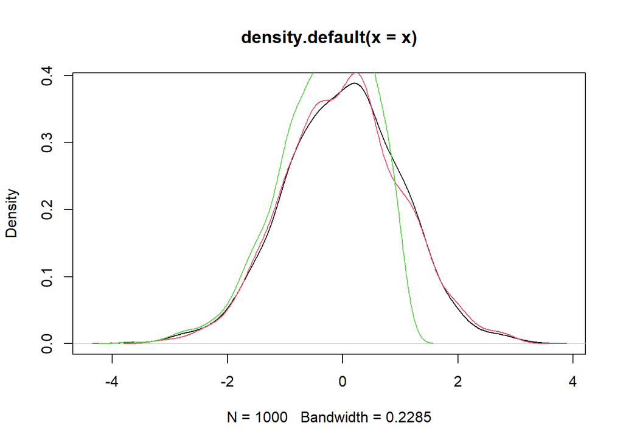

```r
plot(density(x))
lines(density(x[1:n/2]),col=2)
lines(density(x[x<1]),col=3)
```

### Exercise 2: Impact of missing data (2)

*The aim of this exercise is to illustrate the impact of different missing data mechanisms in a study comparing two groups.*

```r
# as a reference, we first simulate a dataset without missing data:
n <- 1000
active <- rnorm(n,135,5)
placebo <- rnorm(n,140,5)
BP <- c(active, placebo) # systolic blood pressure at 6 months measurements
TR <- rep(1:0,each=n) # treatment status; 1 = experimental, 0 = placebo
```

**Question 1:** Is the drug effective?

```r
t.test(BP~TR)
```

```
##
##  Welch Two Sample t-test
##
## data:  BP by TR
## t = 22.322, df = 1998, p-value < 2.2e-16
## alternative hypothesis: true difference in means is not equal to 0
## 95 percent confidence interval:
##  4.525343 5.397118
## sample estimates:
## mean in group 0 mean in group 1
##        139.8622        134.9010
```

**Click to reveal the answer**

Difference in means is approximately 5 and significant. So yes!

Note that the trial could have been much smaller to detect this large effect.

Suppose half (!!) of the placebo-treated participant are lost to follow-up and no blood pressure measurement is available for those subjects:

```r
MISS <- c(rep(0,(n+n/2)),rep(1,n/2))
```

Compare those who have missing values to those without. The function below omits the patient values (e.g. TR) as specified by a missing data mechanism (e.g. MISS). We return the matrix in which it is denoted how much data were specified as missing and what the corresponding mean was of the patient value, given that certain values were omitted (note, we will use this function multiple times):

```r
missing.table <- function(m,Y){
  mat <- matrix(ncol=2,nrow=(ncol(Y)+1))
  colnames(mat) <- c('missings', 'no missings')
  rownames(mat) <- c('n',colnames(Y))
  mat[1,1] <- sum(m==1)
  mat[1,2] <- sum(m==0)
  for (i in 1:ncol(Y)){
    mat[i+1,1] <- mean(Y[,i][m==1])
    mat[i+1,2] <- mean(Y[,i][m==0])
    }
  mat <- round(mat,2)
  return(mat)
}

missing.table(MISS,cbind(TR))
```

```
##    missings no missings
## n       500     1500.00
## TR        0        0.67
```

The corresponding mean of TR is 0 as the missing data only consists of omitted placebo patients (i.e. TR==0).

**Question 2:** The missing data are:

1. Missing completely at random (MCAR), because missingness does not depend on anything (it’s a completely random process)
2. Missing at random (MAR), because missingness depends on an observed variable
3. Missing not at random (MNAR), because missingness depends on unobserved values

**Click to reveal the answer**

The correct answer is B, because missingness depends on an observed variable (the treatment (TR) variable in this case). Note that theoretically it might still be partly MNAR, but you wouldn’t know, since then you need to have information about unobserved variables.

Assess whether the experimental drug is effective:

```r
t.test(BP~TR, subset=MISS==0)
```

```
##
##  Welch Two Sample t-test
##
## data:  BP by TR
## t = 18.343, df = 987.44, p-value < 2.2e-16
## alternative hypothesis: true difference in means is not equal to 0
## 95 percent confidence interval:
##  4.493026 5.569567
## sample estimates:
## mean in group 0 mean in group 1
##        139.9323        134.9010
```

**Question 3:** What do you conclude? Compare the difference in means to the effect estimated in the data without missings.

**Click to reveal the answer**

The difference in means between the two groups in a complete case analysis is still unbiased. How come, even since we know that the data are missing at random? Missing data are missing at random, which means in this case that given (or conditional on) the variable(s) that predict missingness (in this case on the outcome) this missingness is completely at random. To put it differently, missingness on the outcomes here depends entirely on treatment status. So within the groups of treatment and placebo, missingness is completely at random and will not affect the estimate of the mean (see exercise 1). And the difference between two unbiased means will thus be unbiased too.

Let’s suppose a different missing data mechanism. All outcomes (i.e. TR) are missing when the recordings of systolic blood pressure at 6 months are above 140:

```r
MISS <- 1*(BP>140)
```

Compare those who have missing values to those without:

```r
missing.table(MISS,cbind(TR))
```

```
##    missings no missings
## n    637.00     1363.00
## TR     0.22        0.63
```

**Question 4:** The missing data are:

1. Missing completely at random (MCAR), because missingness does not depend on anything (it’s a completely random process)
2. Missing at random (MAR), because missingness depends on an observed variable
3. Missing not at random (MNAR), because missingness depends on unobserved values

**Click to reveal the answer**

The correct answer is C.

Assess whether the experimental drug is effective:

```r
t.test(BP~TR, subset=MISS==0)
```

```
##
##  Welch Two Sample t-test
##
## data:  BP by TR
## t = 11.663, df = 1273.7, p-value < 2.2e-16
## alternative hypothesis: true difference in means is not equal to 0
## 95 percent confidence interval:
##  1.901869 2.671045
## sample estimates:
## mean in group 0 mean in group 1
##        135.9345        133.6481
```

**Question 5:** What do you conclude? Compare the difference in means to the effect estimated in the data without missings (question 1).

**Click to reveal the answer**

Estimated effect differs from truth → bias. This is because the missing outcomes were dependent on the true underlying but unobserved outcome values (MNAR). The difference between the estimated difference and the truth reflects the bias.

Let’s suppose an even more extreme missing data mechanism, in which missingness depends on the actual systolic blood pressure value plus treatment status combined:

```r
MISS <- 1*(BP>median(BP[TR==0])&TR==0 | BP<median(BP[TR==1])&TR==1)
missing.table(MISS,cbind(TR))
```

```
##    missings no missings
## n     1e+03       1e+03
## TR    5e-01       5e-01
```

**Question 6:** Compare those who have missing values to those without. What do you conclude?

**Click to reveal the answer**

This table suggests that maybe missing data are missing completely at random. Does that correspond to the missing data mechanism? No, because missingness on the outcome depended on unobserved values of BP, and of observed values of treatment status. Note that in real life, you wouldn’t know that mechanism and this table - that was also presented this morning in lecture 1 - would, in RCTs, falsely suggest that missing data are MCAR.

**Question 7:** The missing data are:

1. Missing completely at random (MCAR), because missingness does not depend on anything (it’s a completely random process)
2. Missing at random (MAR), because missingness depends on an observed variable
3. Missing not at random (MNAR), because missingness depends on unobserved values

**Click to reveal the answer**

The correct answer is C. Only the combination of SBP and treatment completely explain the missingness. For those cases BP is not observed and as such it is MNAR.

Assess whether the experimental drug is effective:

```r
t.test(BP~TR, subset=MISS==0)
```

```
##
##  Welch Two Sample t-test
##
## data:  BP by TR
## t = -15.535, df = 993.84, p-value < 2.2e-16
## alternative hypothesis: true difference in means is not equal to 0
## 95 percent confidence interval:
##  -3.311140 -2.568445
## sample estimates:
## mean in group 0 mean in group 1
##        135.9104        138.8502
```

**Question 8:** What do you conclude? Compare the difference in means to the effect estimated in the data without missings.

**Click to reveal the answer**

Estimated effect differs from truth → bias. This is because the missing outcomes were dependent on the true underlying but unobserved outcome values (MNAR). The difference between the estimated difference and the truth reflects the bias.

### Exercise 3: Impact of missing data (3)

*The aim of this exercise is to illustrate the impact of missing data when relating two normally distributed variables - regardless of the study design.*

We first simulate a dataset without missing data (using a seed so you can compare results with peers):

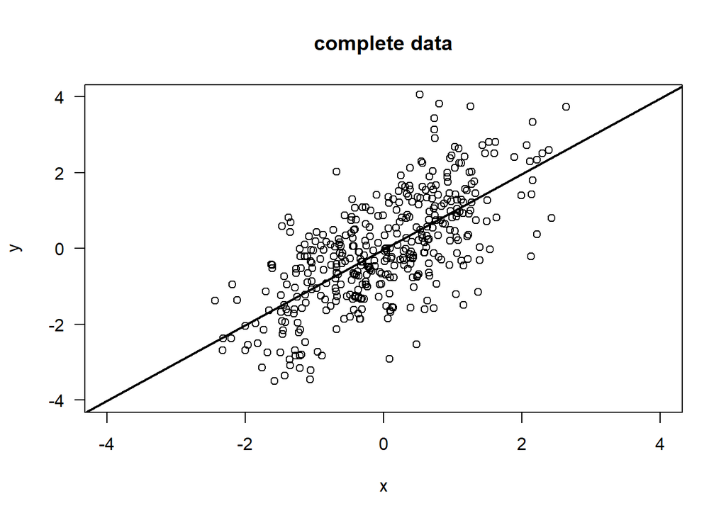

```r
set.seed(10)
n <- 400
x <- rnorm(n)
y <- x + rnorm(n)

plot(x,y,xlim=c(-4,4),ylim=c(-4,4),las=1, main="complete data")
abline(lm(y~x),col=1,lwd=2)
```

On these ‘complete data’ we will impose different patterns of missing data. Each time, we (a) plot the observed data, (b) fit a linear model of y against x, based on the observed data only, (c) add the fitted regression line, and compare to the ‘true’ regression line and finally (d) explain what you see.

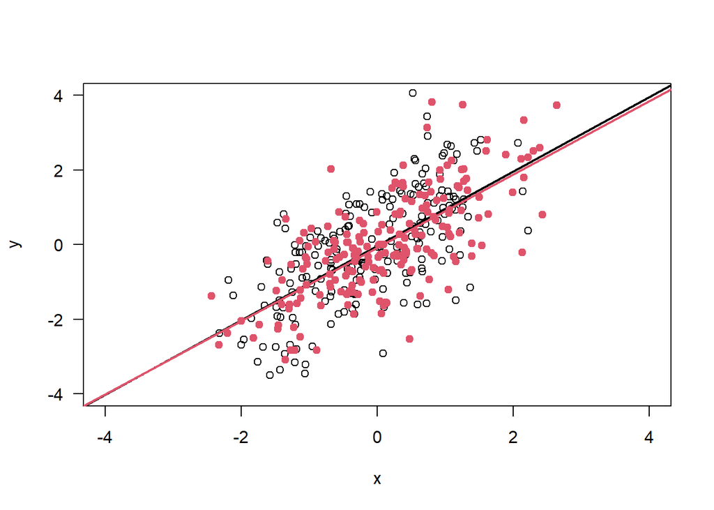

```r
# impose pattern of missingness
select <- rep(0:1,each=n/2)

# plot observed data
plot(x,y,xlim=c(-4,4),ylim=c(-4,4),las=1)

# fit linear model of y against x, using observed data
abline(lm(y~x),col=1,lwd=2)

# plot values based on pattern of missing data
points(x[select==1], y[select==1],pch=21,bg=2,col=2)

# fit linear model of y against x, using selected data
abline(lm(y~x,subset=select==1),col=2,lwd=2)
```

Apply different missing data mechanisms, e.g.:

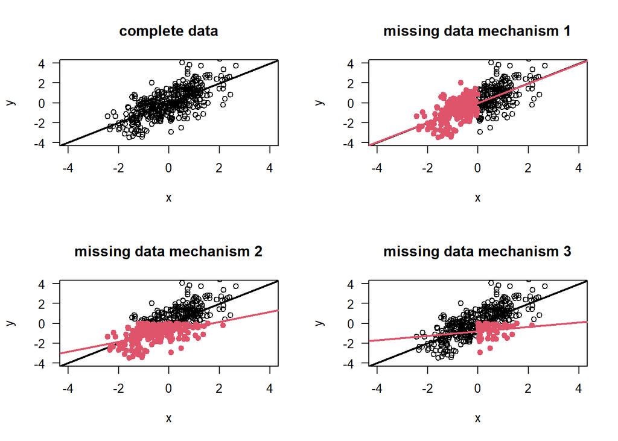

```r
par(mfrow=c(2,2))

plot(x,y,xlim=c(-4,4),ylim=c(-4,4),las=1, main="complete data")
abline(lm(y~x),col=1,lwd=2)

select <- 1*(x<0)
plot(x,y,xlim=c(-4,4),ylim=c(-4,4),las=1,main="missing data mechanism 1")
abline(lm(y~x),col=1,lwd=2)
points(x[select==1], y[select==1],pch=21,bg=2,col=2)
abline(lm(y~x,subset=select==1),col=2,lwd=2)

select <- (y<0)
plot(x,y,xlim=c(-4,4),ylim=c(-4,4),las=1,main="missing data mechanism 2")
abline(lm(y~x),col=1,lwd=2)
points(x[select==1], y[select==1],pch=21,bg=2,col=2)
abline(lm(y~x,subset=select==1),col=2,lwd=2)

select <- (y<0 & x>0)
plot(x,y,xlim=c(-4,4),ylim=c(-4,4),las=1,main="missing data mechanism 3")
abline(lm(y~x),col=1,lwd=2)
points(x[select==1], y[select==1],pch=21,bg=2,col=2)
abline(lm(y~x,subset=select==1),col=2,lwd=2)
```

These are generalizations of exercises 1 and 2. If missingness on the outcome depends on the predictor (or treatment status) and you do the analysis conditional on that predictor (or stratified by treatment status), the estimated regression line is unbiased. However, if missingness depends on the value of the outcome itself (MNAR), the estimated regression line is biased.

**Question 1:** Try it the other way around! Without looking at the plot etc., first think what you expect to see, and explain why that is. Formulate a missing data mechanism and check if it matches with your expectations.

### Exercise 4: Last-observation-carried-forward

*The aim of this exercise is to apply and assess the last-observation-carried-forward (LOCF) method to deal with missing data in case of repeated measurements of a study variable, determinant or outcome.*

For this exercise you will use a dataset that is available in `R`. It’s called Orange. Information about the dataset can be found by `?Orange`.

Attach the data and have a quick look:

```r
summary(Orange)
```

```
##  Tree       age         circumference
##  3:7   Min.   : 118.0   Min.   : 30.0
##  1:7   1st Qu.: 484.0   1st Qu.: 65.5
##  5:7   Median :1004.0   Median :115.0
##  2:7   Mean   : 922.1   Mean   :115.9
##  4:7   3rd Qu.:1372.0   3rd Qu.:161.5
##        Max.   :1582.0   Max.   :214.0
```

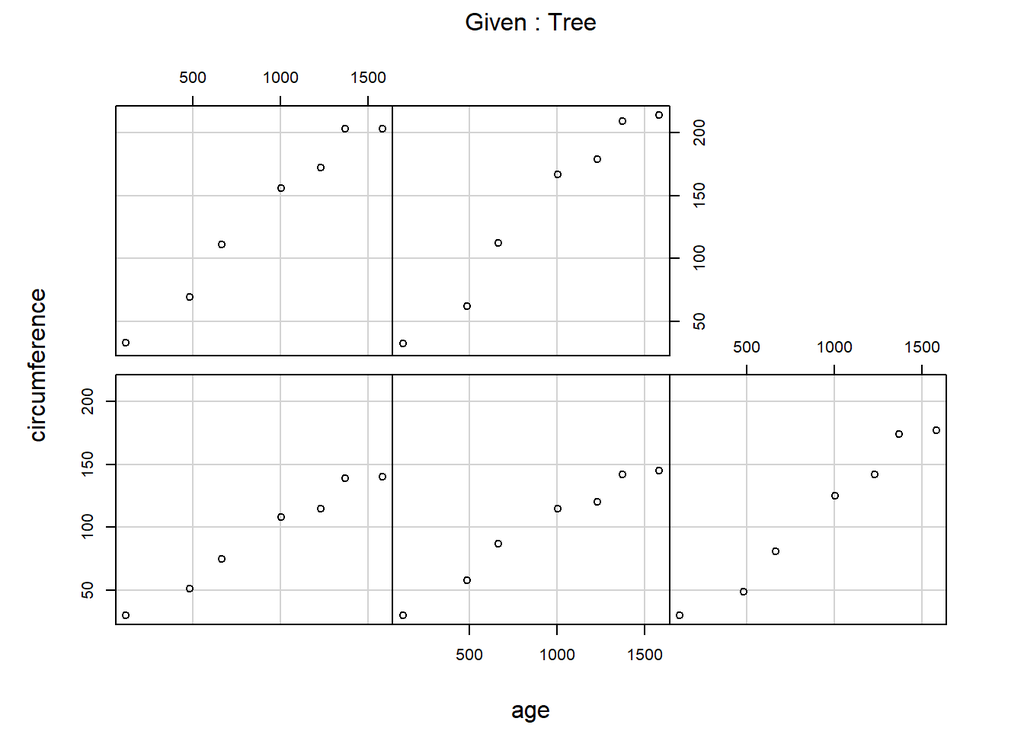

```r
coplot(circumference~age|Tree, show.given=FALSE, data = Orange)
```

Estimate the relation between the age of a tree and its circumference by fitting a random effects model, with a random intercept and a fixed slope. **Note that we will go into mixed models in week 4 and 5 of the course. So do not worry if you do not understand them fully at this point.** Note, you first need to install the lme4 library, we use version 1.1.23:

```r
library(lme4)
summary(lmer(circumference~ age + (1|Tree), data = Orange))
```

```
## Linear mixed model fit by REML ['lmerMod']
## Formula: circumference ~ age + (1 | Tree)
##
## REML criterion at convergence: 303.2
##
## Scaled residuals:
##     Min      1Q  Median      3Q     Max
## -1.8781 -0.6743  0.2320  0.5053  1.5416
##
## Random effects:
##  Groups   Name        Variance Std.Dev.
##  Tree     (Intercept) 389.6    19.74
##  Residual             232.9    15.26
## Number of obs: 35, groups:  Tree, 5
##
## Fixed effects:
##              Estimate Std. Error t value
## (Intercept) 17.399650  10.423696   1.669
## age          0.106770   0.005321  20.066
##
## Correlation of Fixed Effects:
##     (Intr)
## age -0.471
```

For ease of interpretation, we may want to model the age effect per year instead of days:

```r
summary(lmer(circumference~ I(age/365.25) + (1|Tree), data = Orange))
```

```
## Linear mixed model fit by REML ['lmerMod']
## Formula: circumference ~ I(age/365.25) + (1 | Tree)
##
## REML criterion at convergence: 291.4
##
## Scaled residuals:
##     Min      1Q  Median      3Q     Max
## -1.8781 -0.6743  0.2320  0.5053  1.5416
##
## Random effects:
##  Groups   Name        Variance Std.Dev.
##  Tree     (Intercept) 389.6    19.74
##  Residual             232.9    15.26
## Number of obs: 35, groups:  Tree, 5
##
## Fixed effects:
##               Estimate Std. Error t value
## (Intercept)     17.400     10.424   1.669
## I(age/365.25)   38.998      1.943  20.066
##
## Correlation of Fixed Effects:
##             (Intr)
## I(g/365.25) -0.471
```

**Question 1:** What is your interpretation?

**Click to reveal the answer**

The circumference of an orange tree increases by almost 39 mm per year.

```r
Orange$circumference_obs <- Orange$circumference
Orange$circumference_obs[Orange$Tree != 1 & Orange$age > 670] <- NA

summary(lmer(circumference_obs~ I(age/365.25) + (1|Tree), data = Orange))
```

```
## Linear mixed model fit by REML ['lmerMod']
## Formula: circumference_obs ~ I(age/365.25) + (1 | Tree)
##
## REML criterion at convergence: 141.2
##
## Scaled residuals:
##      Min       1Q   Median       3Q      Max
## -1.12620 -0.49462 -0.08488  0.19297  2.28395
##
## Random effects:
##  Groups   Name        Variance Std.Dev.
##  Tree     (Intercept)  33.9     5.822
##  Residual             144.6    12.024
## Number of obs: 19, groups:  Tree, 5
##
## Fixed effects:
##               Estimate Std. Error t value
## (Intercept)     23.102      5.599   4.126
## I(age/365.25)   31.787      2.650  11.994
##
## Correlation of Fixed Effects:
##             (Intr)
## I(g/365.25) -0.724
```

**Question 2:** What is the impact of these missing observations?

**Click to reveal the answer**

The circumference of an orange tree increases by almost 32 mm per year, which differs from the 39 mm found earlier, due to the missing observations.

In order to perform LOCF, as a means of dealing with the missing observations, use the following function:

```r
LOCF.fun <- function(x){
  goodIdx <- !is.na(x)
  goodVals <- c(NA,x[goodIdx])
  fillIdx <- cumsum(goodIdx) + 1
  x.locf <- goodVals[fillIdx]
  return(x.locf)
}
```

We can then apply LOCF:

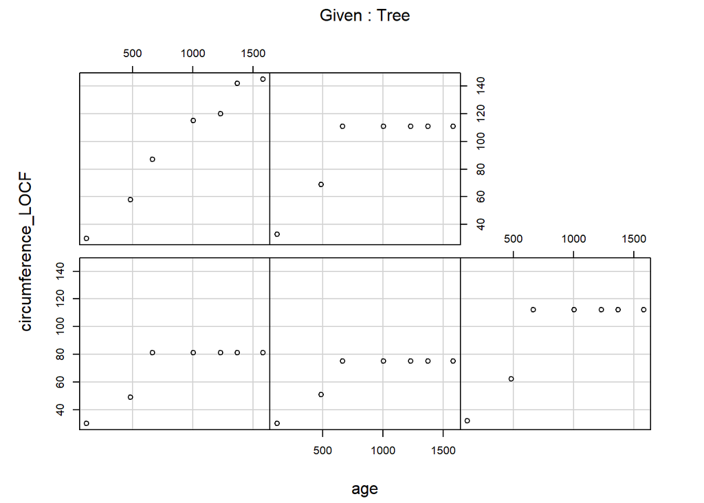

```r
Orange$circumference_LOCF <- unlist(by(Orange$circumference_obs,Orange$Tree,LOCF.fun))
coplot(circumference_LOCF~age|Tree, show.given=FALSE, data = Orange)
```

```r
summary(lmer(circumference_LOCF~ I(age/365.25) + (1|Tree), data = Orange))
```

```
## Linear mixed model fit by REML ['lmerMod']
## Formula: circumference_LOCF ~ I(age/365.25) + (1 | Tree)
##
## REML criterion at convergence: 295.4
##
## Scaled residuals:
##      Min       1Q   Median       3Q      Max
## -1.63209 -0.73534 -0.06688  0.64091  1.93134
##
## Random effects:
##  Groups   Name        Variance Std.Dev.
##  Tree     (Intercept) 210.1    14.50
##  Residual             287.1    16.94
## Number of obs: 35, groups:  Tree, 5
##
## Fixed effects:
##               Estimate Std. Error t value
## (Intercept)     39.034      8.939   4.367
## I(age/365.25)   17.901      2.158   8.296
##
## Correlation of Fixed Effects:
##             (Intr)
## I(g/365.25) -0.609
```

**Question 3:** What is the impact of using LOCF?

**Click to reveal the answer**

According to this model, the circumference of an orange tree increases by almost 18 mm per year, which is considerably different from the 39 mm found before. Note, in this case the bias is towards the null effect, but that is not necessarily the case with LOCF.

**Question 4:** In this example, it´s obvious that LOCF isn´t an appropriate choice (since the circumference of trees is expected to increase as time goes by). Can you think of (medical) example, in which observations of repeated measurements are missing and LOCF also may not be an appropriate solution to that problem?

**Click to reveal the answer**

*Short answer:* Basically, any situation where repeated measurements of a study variable are at issue, and that are susceptible to changes over time.

*Long answer:*

Say the exposure (or covariate) is weight and is to be recorded every month. Now, for some patients some weight measurements are missing before the event of interest (some cardiovascular or cancer event) has occurred. Obviously, we cannot simply impute the latest recorded value, as the missing observations may be related to the occurred outcome and also may change over time anyhow.

Say the outcome is (time-to) death, and death is only recorded if it occurs in the hospital (as in hospital mortality). Patients who are discharged early (and not followed up outside the hospital), are implicitly recorded as LOCF - i.e. not death (alive).

### Exercise 5: Complete and available case analysis

*The aim of this exercise is to understand the difference between a complete case analysis and an available case analysis.*

The table below shows a (small) dataset of 4 predictors (X1-X4) and 1 outcome variable (Y).

| **X1** | **X2** | **X3** | **X4** | **Y** |
| --- | --- | --- | --- | --- |
| NA | 0.729475 | 0.856758 | 0.422941 | 1 |
| NA | 0.190514 | 0.577857 | 0.574266 | 0 |
| 0.687772 | NA | 0.420187 | 0.770083 | 1 |
| 0.661445 | NA | 0.26531 | 0.243962 | 1 |
| 0.538066 | 0.827482 | NA | 0.248112 | 0 |
| 0.485879 | 0.258925 | NA | 0.373167 | 0 |
| 0.136305 | 0.296076 | 0.096076 | NA | 0 |
| 0.076464 | 0.304909 | 0.204944 | NA | 1 |
| 0.511494 | 0.745145 | 0.608727 | 0.671469 | 0 |
| 0.139432 | 0.988963 | 0.554117 | 0.907026 | 1 |

**Question 1:** What is the percentage of missing observations per predictor?

**Click to reveal the answer**

Exactly 20% for each predictor.

**Question 2:** If you were to perform a complete case analysis, what percentage of subjects would be included in the analysis?

**Click to reveal the answer**

There are only 2 out of 10 subjects for whom all predictors are observed, i.e., 2 out of 10 (20%) have complete data.

**Question 3:** If you were to perform an available case analysis, what percentage of subjects would be included in an analysis of the predictors X1, X2, and X3 in relation to the outcome Y?

**Click to reveal the answer**

Only 4 out of 10 subjects have information available about the predictors X1, X2, and X3, so 40% of subjects will be included in the analysis.

**Question 4:** Suppose you do a study including 100 predictors. For each predictor only 1% of observations is missing. If you were to perform a complete case analysis, what percentage of subjects would be included in the analysis given that:

1. It is the same group of people who have missing information for all 100 predictors.
2. All patients miss exactly 1% of their predictors.
3. The missingness is completely at random for all patients (meaning they can have more than 1% missing)?

**(1):** Click to reveal the answer**

If it is the same group of people who have missing information for all 100 predictors, then 99% of all subjects will have complete data.

**(2):** Click to reveal the answer**

If each person has missing information for exactly 1 different predictor, then all subjects will have missing information for one of the predictors, and consequently nobody will be included in the complete case analysis.

**(3):** Click to reveal the answer**

If the predictor that is missing is completely at random for each patient, then: .99^100 = .366, so 36.6% are expected to be in the analysis.